# PEC 1 DATOS ÓMICOS

Sofia Linares

2024-11-02

1. Seleccionar un dataset de metabolómica que podéis obtener de o Este repositorio de github: https://github.com/nutrimetabolomics/metaboData/

Se selecciona el dataset: 2024-Cachexia

2. Una vez descargados los datos cread un contenedor del tipo SummarizedExperiment que contenga los datos y los metadatos (información acerca del dataset, las filas y las columnas). La clase SummarizedExperiment es una extensión de ExpressionSet y muchas aplicaciones o bases de datos (como metabolomicsWorkbench) lo utilizan en vez de usar expressionSet.

```r
library(SummarizedExperiment)
library(readr)

# Leer el archivo
human_cachexia <- read_csv("C:/Users/sofia/OneDrive/Escritorio/Master Bioinformática y Bioestadística UOC/Análisis de datos ómicos/PEC 1/human_cachexia.csv")
# Extraer los datos numéricos, excluyendo Patient ID y Muscle loss
datos <- as.matrix(human_cachexia[, -c(1, 2)])

# Transponer la matriz de datos para que las filas sean los metabolitos y las columnas los pacientes
datos <- t(datos)

# Crear rowData con información de los metabolitos
row_data <- DataFrame(variable = rownames(datos))
rownames(row_data) <- rownames(datos)  # Asignar nombres de metabolitos a rowData

# Crear colData con la variable 'Muscle loss' para cada paciente
col_data <- DataFrame(muscle_loss = human_cachexia$`Muscle loss`)
rownames(col_data) <- human_cachexia$`Patient ID`

# Añadir metadatos para describir el experimento
metadata <- list(
    titulo = "Conjunto de Datos del Estudio de Caquexia Humana",
    descripcion = "Este conjunto de datos incluye mediciones de marcadores metabólicos y el estado de pérdida muscular en pacientes de un estudio sobre caquexia. Este es el famoso conjunto de datos de caquexia utilizado en varios tutoriales de MetaboAnalyst.",
    fuente = "MetabolomicsWorkbench",
    url = "https://rest.xialab.ca/api/download/metaboanalyst/human_cachexia.csv",
    sanity_check = "Satisfactoria",
    sample_pairing = "Las muestras no están emparejadas.",
    grupos = "Se detectaron 2 grupos en las muestras: Control y Cachexicos.",
    valores_datos = "Todos los valores de datos son numéricos.",
    missing_values = "Se detectaron un total de 0 (0%) valores faltantes."
)


# Crear el SummarizedExperiment
se <- SummarizedExperiment(
    assays = list(counts = datos),
    rowData = row_data,
    colData = col_data,
    metadata = metadata
)

str(se)
```

```
## Formal class 'SummarizedExperiment' [package "SummarizedExperiment"] with 5 slots
##   ..@ colData        :Formal class 'DFrame' [package "S4Vectors"] with 6 slots
##   .. .. ..@ rownames       : chr [1:77] "PIF_178" "PIF_087" "PIF_090" "NETL_005_V1" ...
##   .. .. ..@ nrows          : int 77
##   .. .. ..@ elementType    : chr "ANY"
##   .. .. ..@ elementMetadata: NULL
##   .. .. ..@ metadata       : list()
##   .. .. ..@ listData       :List of 1
##   .. .. .. ..$ muscle_loss: chr [1:77] "cachexic" "cachexic" "cachexic" "cachexic" ...
##   ..@ assays         :Formal class 'SimpleAssays' [package "SummarizedExperiment"] with 1 slot
##   .. .. ..@ data:Formal class 'SimpleList' [package "S4Vectors"] with 4 slots
##   .. .. .. .. ..@ listData       :List of 1
##   .. .. .. .. .. ..$ counts: num [1:63, 1:77] 40.9 65.4 18.7 26.1 71.5 ...
##   .. .. .. .. .. .. ..- attr(*, "dimnames")=List of 2
##   .. .. .. .. .. .. .. ..$ : chr [1:63] "1,6-Anhydro-beta-D-glucose" "1-Methylnicotinamide" "2-Aminobutyrate" "2-Hydroxyisobutyrate" ...
##   .. .. .. .. .. .. .. ..$ : NULL
##   .. .. .. .. ..@ elementType    : chr "ANY"
##   .. .. .. .. ..@ elementMetadata: NULL
##   .. .. .. .. ..@ metadata       : list()
##   ..@ NAMES          : chr [1:63] "1,6-Anhydro-beta-D-glucose" "1-Methylnicotinamide" "2-Aminobutyrate" "2-Hydroxyisobutyrate" ...
##   ..@ elementMetadata:Formal class 'DFrame' [package "S4Vectors"] with 6 slots
##   .. .. ..@ rownames       : NULL
##   .. .. ..@ nrows          : int 63
##   .. .. ..@ elementType    : chr "ANY"
##   .. .. ..@ elementMetadata: NULL
##   .. .. ..@ metadata       : list()
##   .. .. ..@ listData       :List of 1
##   .. .. .. ..$ variable: chr [1:63] "1,6-Anhydro-beta-D-glucose" "1-Methylnicotinamide" "2-Aminobutyrate" "2-Hydroxyisobutyrate" ...
##   ..@ metadata       :List of 9
##   .. ..$ titulo        : chr "Conjunto de Datos del Estudio de Caquexia Humana"
##   .. ..$ descripcion   : chr "Este conjunto de datos incluye mediciones de marcadores metabólicos y el estado de pérdida muscular en paciente"| __truncated__
##   .. ..$ fuente        : chr "MetabolomicsWorkbench"
##   .. ..$ url           : chr "https://rest.xialab.ca/api/download/metaboanalyst/human_cachexia.csv"
##   .. ..$ sanity_check  : chr "Satisfactoria"
##   .. ..$ sample_pairing: chr "Las muestras no están emparejadas."
##   .. ..$ grupos        : chr "Se detectaron 2 grupos en las muestras: Control y Cachexicos."
##   .. ..$ valores_datos : chr "Todos los valores de datos son numéricos."
##   .. ..$ missing_values: chr "Se detectaron un total de 0 (0%) valores faltantes."
```

La matriz “datos” contiene los resultados obtenidos de los metabolitos a estudio, excluyendo tanto Patient ID como Muscle loss.

En colData se incluye la variable Muscle loss, que tiene la información de los pacientes (control y cachexic).

3. Llevad a cabo una exploración del dataset que os proporcione una visión general del mismo en la línea de lo que hemos visto en las actividades.

Incialmente se lleva a cabo un análisis descriptivo de los datos:

```r
#Estadística descriptiva sobre los metabolitos:

library(matrixStats)

# Calcular medias, varianzas, mínimo, máximo y mediana para cada metabolito
metabolito_media <- rowMeans(datos, na.rm = TRUE)
metabolito_varianza <- rowVars(datos, na.rm = TRUE)
metabolito_minimo <- rowMins(datos, na.rm = TRUE)
metabolito_maximo <- rowMaxs(datos, na.rm = TRUE)
metabolito_mediana <- rowMedians(datos, na.rm = TRUE)

# Crear un dataframe con los resultados
metabolitos_resumen <- data.frame(
  Metabolito = rownames(datos),
  Media = metabolito_media,
  Varianza = metabolito_varianza,
  Minimo = metabolito_minimo,
  Maximo = metabolito_maximo,
  Mediana = metabolito_mediana
)


print(metabolitos_resumen[, -1])
```

```
##                                  Media     Varianza  Minimo   Maximo Mediana
## 1,6-Anhydro-beta-D-glucose  105.630390 1.690666e+04    4.71   685.40   45.60
## 1-Methylnicotinamide         71.573636 1.774032e+04    6.42  1032.77   36.60
## 2-Aminobutyrate              18.159740 7.625620e+02    1.28   172.43   10.49
## 2-Hydroxyisobutyrate         37.250649 5.739286e+02    4.85    93.69   32.46
## 2-Oxoglutarate              145.087143 1.173214e+05    5.53  2465.13   55.15
## 3-Aminoisobutyrate           76.756364 3.648644e+04    2.61  1480.30   22.65
## 3-Hydroxybutyrate            21.717013 6.863826e+02    1.70   175.91   11.70
## 3-Hydroxyisovalerate         21.647792 6.223075e+02    0.92   164.02   12.55
## 3-Indoxylsulfate            218.879221 3.875730e+04   27.66  1043.15  144.03
## 4-Hydroxyphenylacetate      112.021039 1.459568e+04   15.49   796.32   70.11
## Acetate                      66.141429 6.274630e+03    3.49   411.58   39.65
## Acetone                      11.427013 5.503919e+02    2.29   206.44    7.10
## Adipate                      24.756364 2.542872e+03    1.55   327.01   10.18
## Alanine                     273.562338 6.604130e+04   16.78  1312.91  194.42
## Asparagine                   62.283636 2.910765e+03    6.69   273.14   42.10
## Betaine                      90.324675 6.842658e+03    2.29   391.51   64.72
## Carnitine                    52.085065 5.467736e+03    2.18   487.85   23.81
## Citrate                    2235.345974 4.694016e+06   59.74 13629.61 1790.05
## Creatine                    126.831948 7.464718e+04    2.75  1863.11   44.26
## Creatinine                 8733.971818 4.195953e+07 1002.25 33860.35 7631.20
## Dimethylamine               358.166104 9.475490e+04   41.26  1556.20  304.90
## Ethanolamine                276.260390 6.339341e+04   16.12  1436.55  204.38
## Formate                     147.402987 3.503676e+04    6.42  1480.30   95.58
## Fucose                       88.668831 6.505793e+03    5.70   407.48   61.56
## Fumarate                      8.440130 2.092959e+02    0.79    96.54    4.10
## Glucose                     559.844545 1.923604e+06   26.84  8690.62  210.61
## Glutamine                   306.871558 8.466465e+04   23.34  1685.81  225.88
## Glycine                     880.717403 9.019166e+05   38.09  5064.45  528.48
## Glycolate                   187.989351 3.255260e+04    5.42   720.54  130.32
## Guanidoacetate               86.370519 6.904833e+03    7.03   561.16   64.72
## Hippurate                  2286.837662 8.238722e+06   92.76 19341.34 1224.15
## Histidine                   292.637532 9.781686e+04   14.15  1863.11  174.16
## Hypoxanthine                 61.097662 3.309677e+03    3.78   265.07   40.04
## Isoleucine                    8.709091 4.809693e+01    1.79    40.04    7.17
## Lactate                     158.456494 1.767373e+05    7.32  3640.95   81.45
## Leucine                      24.363636 4.629229e+02    2.51   103.54   19.11
## Lysine                      108.794156 1.604259e+04   10.49   788.40   69.41
## Methylamine                  17.376234 1.936370e+02    1.51    52.46   14.73
## Methylguanidine              15.324545 3.939374e+02    1.70   141.17    7.85
```

[output cut: 9 more lines]

```
## Tartrate                     40.004026 1.070861e+04    2.20   837.15   12.94
## Taurine                     525.123506 4.540721e+05   17.81  4272.69  249.64
## Threonine                    95.357403 7.586000e+03    8.25   450.34   64.07
## Trigonelline                270.436104 1.584725e+05   10.07  2252.96  114.43
## Trimethylamine N-oxide      652.156883 8.283724e+05   55.70  5486.25  383.75
## Tryptophan                   66.243117 3.173443e+03    8.67   259.82   46.99
## Tyrosine                     81.757273 6.930310e+03    4.22   539.15   60.34
## Uracil                       35.557662 1.225203e+03    3.10   179.47   27.39
## Valine                       35.667013 8.819335e+02    4.10   160.77   33.12
## Xylose                      100.933377 6.260821e+04   10.07  2164.62   50.40
## cis-Aconitate               204.219740 7.736297e+04   12.94  1863.11  129.02
## myo-Inositol                135.397532 2.899067e+04   11.59   854.06   78.26
## trans-Aconitate              40.630390 1.565528e+03    4.90   217.02   26.84
## pi-Methylhistidine          370.288312 2.816311e+05   11.36  2697.28  162.39
## tau-Methylhistidine          89.686883 5.965873e+03    8.00   317.35   68.72
```

A continuación, se realiza un análisis de correlación de las variables numéricas:

```r
library(corrplot)
# Obtener los nombres de los metabolitos desde las filas de 'datos'
metabolitos <- rownames(datos)

# Reemplazar los nombres de los metabolitos por números
nombres_numericos <- as.character(1:length(metabolitos))

# Crear las equivalencias (número : nombre del metabolito)
equivalencias_texto <- paste(nombres_numericos, ":", metabolitos)

# Imprimir las equivalencias en la consola
cat("Equivalencias de los metabolitos:\n")
```

```
## Equivalencias de los metabolitos:
```

```r
cat(equivalencias_texto, sep = "\n")
```

```
## 1 : 1,6-Anhydro-beta-D-glucose
## 2 : 1-Methylnicotinamide
## 3 : 2-Aminobutyrate
## 4 : 2-Hydroxyisobutyrate
## 5 : 2-Oxoglutarate
## 6 : 3-Aminoisobutyrate
## 7 : 3-Hydroxybutyrate
## 8 : 3-Hydroxyisovalerate
## 9 : 3-Indoxylsulfate
## 10 : 4-Hydroxyphenylacetate
## 11 : Acetate
## 12 : Acetone
## 13 : Adipate
## 14 : Alanine
## 15 : Asparagine
```

[output cut: 48 more lines]

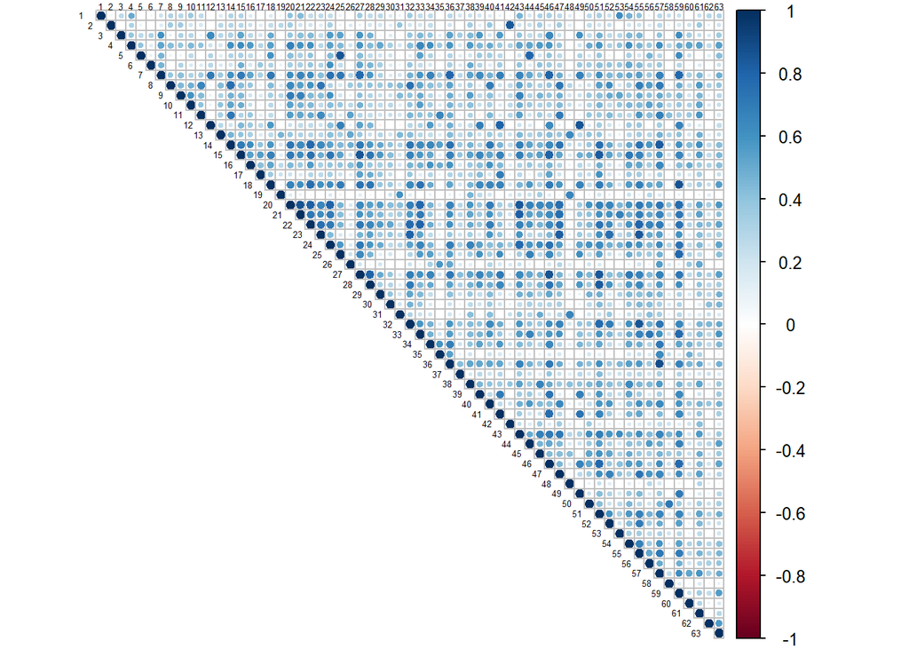

```r
# Calcular la matriz de correlación (usando la transposición de los datos)
correlacion <- cor(t(datos))

# Cambiar los nombres de las filas y columnas de la matriz de correlación a los números
colnames(correlacion) <- rownames(correlacion) <- nombres_numericos

# Crear el gráfico de la matriz de correlación con los nombres numéricos
corrplot(correlacion, method = "circle", type = "upper", tl.col = "black", tl.srt = 0,
         tl.cex = 0.4, tl.offset = 0.5, pch.cex = 1.5)
```

Existe una fuerte correlación positiva en algunas de las variables (azul oscuro), se observan casi todos los puntos con tonalidades azules y por tanto, las correlaciones son positivas en la mayoría de los casos.

Ahora se va a realizar un análisis comparativo de los diferentes metabolitos según al grupo de pacientes que pertenece para buscar si existen diferencias significativas:

```r
# Convertir la variable muscle_loss a factor y obtener los grupos de estudio
se$muscle_loss <- as.factor(se$muscle_loss)
grupos <- se$muscle_loss
table(grupos)
```

```
## grupos
## cachexic  control
##       47       30
```

```r
# Calcula una prueba t para cada metabolito y almacena los p-valores
t_test <- data.frame(
  metabolito = rownames(datos),
  p_valor = apply(datos, 1, function(metabolito) {
    t.test(metabolito ~ grupos)$p.value
  })
)

# Aplica una corrección por comparaciones múltiples (FDR)
t_test$ajustado <- p.adjust(t_test$p_valor, method = "fdr")

# Filtra los metabolitos con diferencias significativas ( p < 0.05)
metabolitos_significativos <- t_test[t_test$ajustado < 0.05, ]
metabolitos_significativos <- metabolitos_significativos[order(metabolitos_significativos$ajustado), ]

# Muestra los metabolitos significativamente diferentes
print(metabolitos_significativos [, -1])
```

```
##                                 p_valor     ajustado
## Leucine                    2.662822e-05 0.0004266252
## N,N-Dimethylglycine        2.114015e-05 0.0004266252
## Quinolinate                2.708732e-05 0.0004266252
## Valine                     1.574212e-05 0.0004266252
## Dimethylamine              5.348990e-05 0.0006739727
## Pyroglutamate              7.289814e-05 0.0007654305
## 3-Hydroxybutyrate          1.334590e-04 0.0010785642
## Creatinine                 1.369605e-04 0.0010785642
## Alanine                    2.960803e-04 0.0020685627
## Glutamine                  3.391600e-04 0.0020685627
## myo-Inositol               3.611776e-04 0.0020685627
## cis-Aconitate              6.190184e-04 0.0032498468
## Serine                     8.173888e-04 0.0039611921
## Tryptophan                 8.885986e-04 0.0039986936
## Threonine                  1.183249e-03 0.0049696457
## Methylamine                1.496975e-03 0.0058943377
## Acetate                    1.740727e-03 0.0064509293
## Fucose                     1.863466e-03 0.0065221322
## Betaine                    2.174920e-03 0.0072115753
## 3-Hydroxyisovalerate       3.458034e-03 0.0100704304
## Asparagine                 3.566603e-03 0.0100704304
## Succinate                  3.676506e-03 0.0100704304
## Trigonelline               3.219917e-03 0.0100704304
## 2-Hydroxyisobutyrate       4.893295e-03 0.0110459347
## 3-Indoxylsulfate           4.849645e-03 0.0110459347
## Formate                    4.909304e-03 0.0110459347
## Histidine                  4.541154e-03 0.0110459347
## Tyrosine                   4.456642e-03 0.0110459347
## Citrate                    5.098507e-03 0.0110760662
## Adipate                    7.515595e-03 0.0152736277
## Pyruvate                   7.357362e-03 0.0152736277
## 2-Aminobutyrate            7.859048e-03 0.0154724998
## Glucose                    9.239445e-03 0.0176389408
## Hippurate                  1.015460e-02 0.0188158774
## Glycine                    1.304117e-02 0.0234741005
## Taurine                    1.418748e-02 0.0248280932
## Trimethylamine N-oxide     1.586788e-02 0.0270182753
## tau-Methylhistidine        1.710741e-02 0.0283622903
## Creatine                   1.984702e-02 0.0309043660
## Ethanolamine               2.011237e-02 0.0309043660
## trans-Aconitate            1.953314e-02 0.0309043660
## O-Acetylcarnitine          2.418993e-02 0.0362848882
## Fumarate                   2.620524e-02 0.0383937250
## Carnitine                  3.192506e-02 0.0457108823
## 1,6-Anhydro-beta-D-glucose 3.531943e-02 0.0494472045
```

Se obtiene un listado de los metabolitos que presentan diferencias significativas (p < 0.05) entre los dos grupos, por tanto, estos metabolitos tendrán, a priori, una mayor asociación con la caquexia.

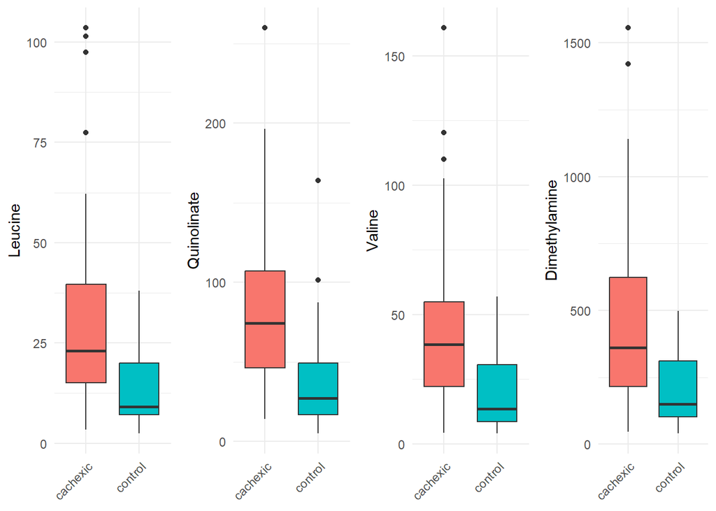

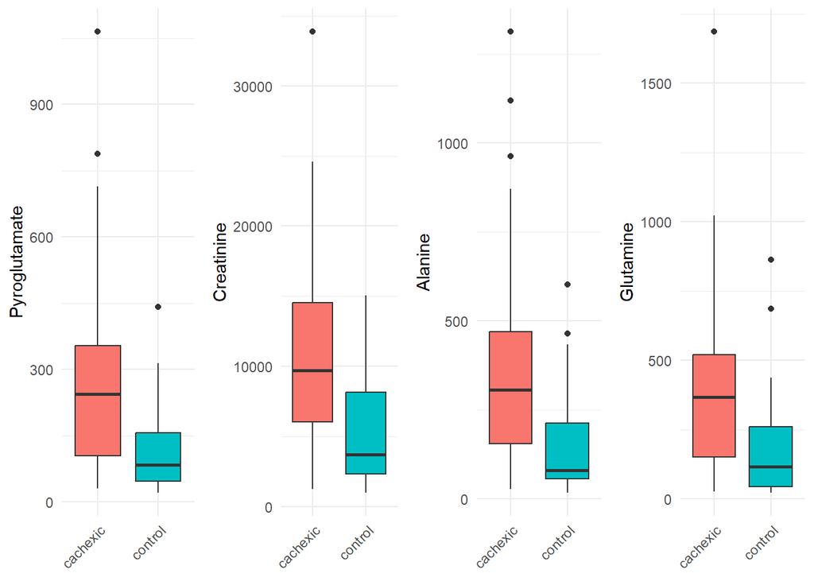

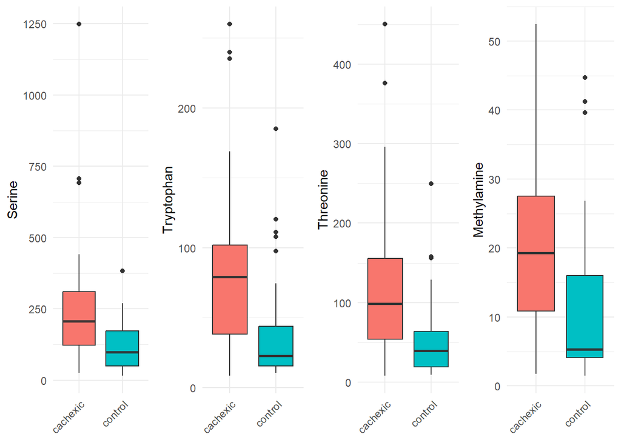

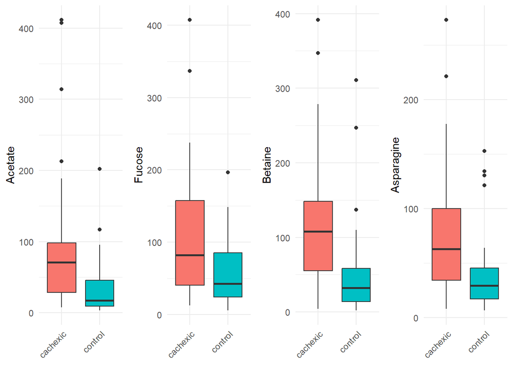

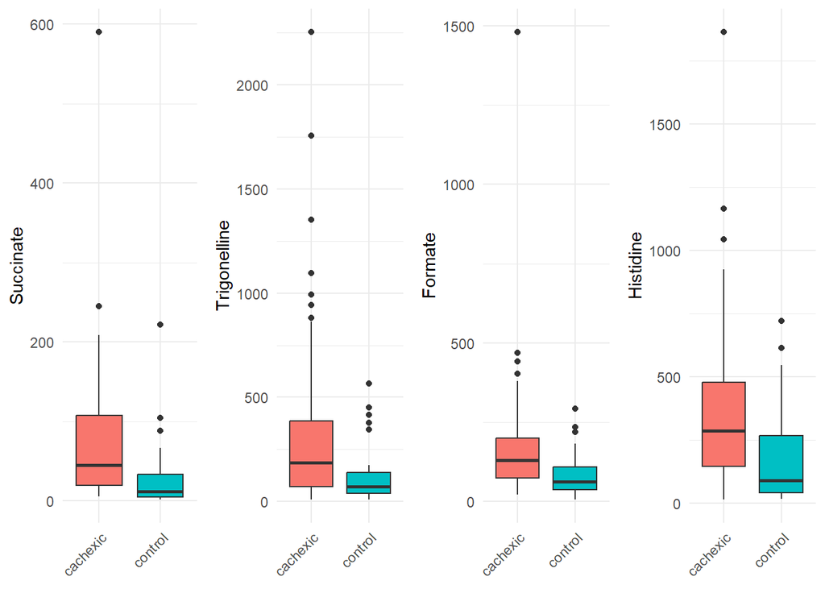

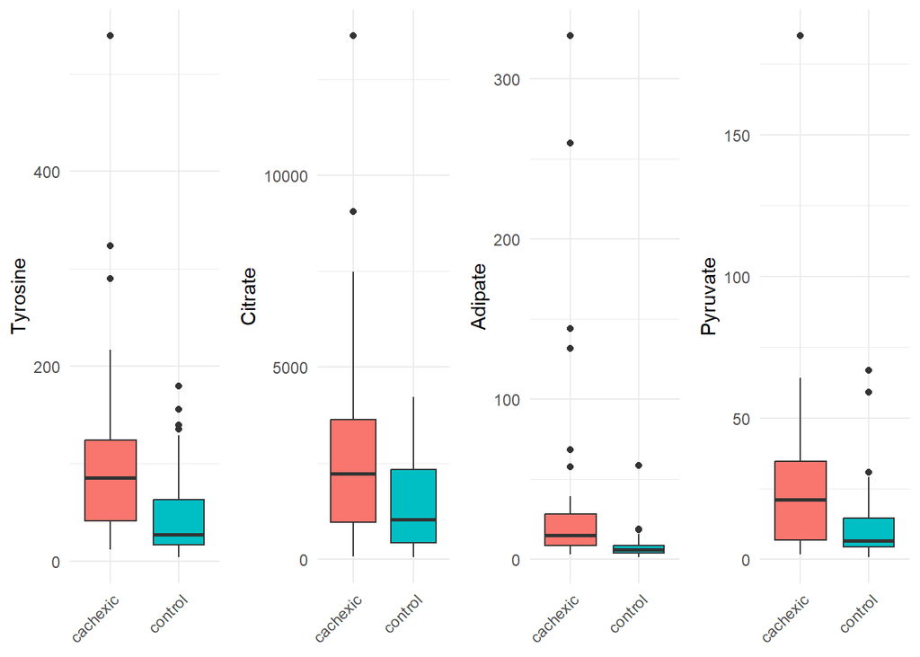

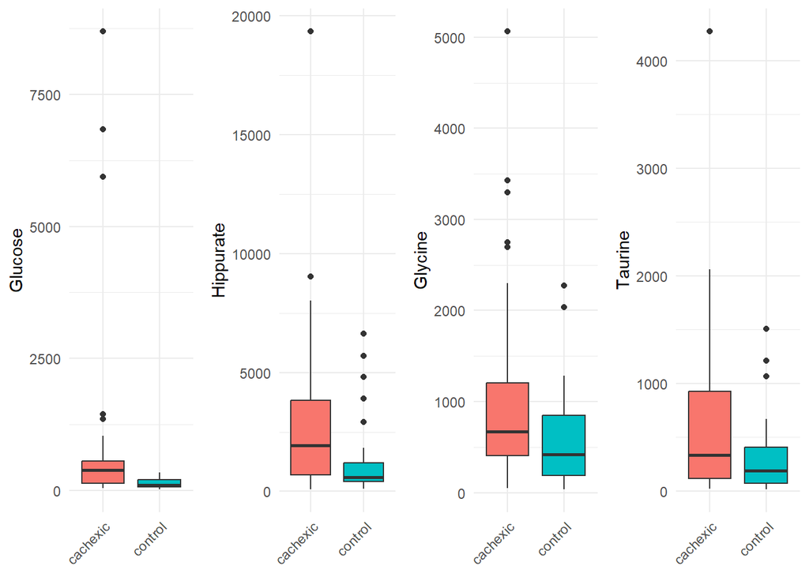

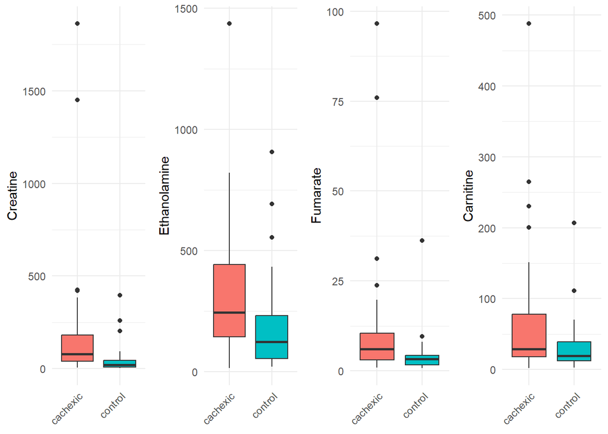

```r
library(ggplot2)
library(dplyr)
library(tidyr)
library(patchwork)
library(ggplot2)
library(gridExtra)
datos_df <- as.data.frame(t(datos))
datos_df$Group <- grupos
colnames(datos_df) <- make.names(colnames(datos_df))



# Crear una lista vacía para almacenar los gráficos
grafico_lista <- list()

for (i in seq_len(nrow(metabolitos_significativos))) {
  metabolito <- metabolitos_significativos$metabolito[i]

  # Verificar si el metabolito está en las columnas de datos_df
  if (metabolito %in% colnames(datos_df)) {
    # Crear el gráfico sin título
    p <- ggplot(datos_df, aes_string(x = "Group", y = metabolito)) +
      geom_boxplot(aes(fill = Group)) +
      labs(x = "Grupo", y = metabolito) +  # Eliminar el título
      theme_minimal() +
      theme(axis.text.x = element_text(angle = 45, hjust = 1),
            legend.position = "none",
            axis.title.x = element_blank())

    # Almacenar el gráfico en la lista
    grafico_lista[[metabolito]] <- p
  }

}
grafico_sublistas <- split(grafico_lista, ceiling(seq_along(grafico_lista) / 4))


for (sublista in grafico_sublistas) {
  do.call(grid.arrange, c(sublista, ncol = 4))
}
```

Los metabolitos que presentan diferencias significativas entre los dos grupos muestran valores más altos en el grupo con caquexia en comparación con el grupo Control.

Nos encontramos con un estudio con una gran cantidad de variables y por tanto, el análisis de componentes principales (PCA) podría ser un buen enfoque ya que transforma un conjunto de variables posiblemente correlacionadas en un conjunto de variables no correlacionadas, reduciendo la dimensionalidad.

```r
datos_pca <- as.data.frame(t(datos))
pca_result <- prcomp(datos_pca, scale. = TRUE)
summary(pca_result)
```

```
## Importance of components:
##                           PC1    PC2     PC3     PC4     PC5    PC6     PC7
## Standard deviation     5.0467 2.2701 1.83311 1.74728 1.65906 1.6130 1.47304
## Proportion of Variance 0.4043 0.0818 0.05334 0.04846 0.04369 0.0413 0.03444
## Cumulative Proportion  0.4043 0.4861 0.53941 0.58787 0.63156 0.6729 0.70730
##                            PC8     PC9    PC10   PC11    PC12    PC13   PC14
## Standard deviation     1.36403 1.24275 1.20650 1.1584 1.05503 1.03620 0.9914
## Proportion of Variance 0.02953 0.02451 0.02311 0.0213 0.01767 0.01704 0.0156
## Cumulative Proportion  0.73683 0.76135 0.78445 0.8057 0.82342 0.84046 0.8561
##                           PC15    PC16    PC17    PC18   PC19    PC20    PC21
## Standard deviation     0.96773 0.89551 0.86788 0.83041 0.8133 0.73918 0.72112
## Proportion of Variance 0.01487 0.01273 0.01196 0.01095 0.0105 0.00867 0.00825
## Cumulative Proportion  0.87093 0.88366 0.89562 0.90656 0.9171 0.92573 0.93399
##                           PC22    PC23    PC24   PC25   PC26    PC27    PC28
## Standard deviation     0.71053 0.64606 0.63389 0.5830 0.5442 0.50539 0.48743
## Proportion of Variance 0.00801 0.00663 0.00638 0.0054 0.0047 0.00405 0.00377
## Cumulative Proportion  0.94200 0.94863 0.95500 0.9604 0.9651 0.96916 0.97293
##                           PC29    PC30    PC31    PC32    PC33    PC34    PC35
## Standard deviation     0.42674 0.42427 0.41483 0.38653 0.35092 0.32424 0.31646
## Proportion of Variance 0.00289 0.00286 0.00273 0.00237 0.00195 0.00167 0.00159
## Cumulative Proportion  0.97582 0.97867 0.98141 0.98378 0.98573 0.98740 0.98899
##                          PC36    PC37    PC38    PC39    PC40    PC41    PC42
## Standard deviation     0.2867 0.28435 0.26060 0.25353 0.24800 0.21896 0.19537
## Proportion of Variance 0.0013 0.00128 0.00108 0.00102 0.00098 0.00076 0.00061
## Cumulative Proportion  0.9903 0.99158 0.99266 0.99368 0.99465 0.99541 0.99602
##                           PC43   PC44    PC45   PC46    PC47   PC48    PC49
## Standard deviation     0.18914 0.1767 0.16864 0.1580 0.15287 0.1380 0.13101
## Proportion of Variance 0.00057 0.0005 0.00045 0.0004 0.00037 0.0003 0.00027
## Cumulative Proportion  0.99659 0.9971 0.99753 0.9979 0.99830 0.9986 0.99888
##                           PC50    PC51    PC52    PC53    PC54    PC55    PC56
## Standard deviation     0.10759 0.10374 0.09853 0.08760 0.08258 0.08049 0.06927
## Proportion of Variance 0.00018 0.00017 0.00015 0.00012 0.00011 0.00010 0.00008
## Cumulative Proportion  0.99906 0.99923 0.99939 0.99951 0.99962 0.99972 0.99979
##                           PC57    PC58    PC59    PC60    PC61    PC62    PC63
## Standard deviation     0.05937 0.05673 0.05088 0.04001 0.02972 0.02789 0.01876
## Proportion of Variance 0.00006 0.00005 0.00004 0.00003 0.00001 0.00001 0.00001
## Cumulative Proportion  0.99985 0.99990 0.99994 0.99997 0.99998 0.99999 1.00000
```

```r
cargas <- pca_result$rotation  # Cargas de cada componente

# Cargas de la Componente Principal 1
cargas_PC1 <- cargas[, 1]
cargas_PC1_ordenadas <- sort(cargas_PC1, decreasing = TRUE)
cargas_PC1_ordenadas
```

```
##                 Creatinine                  Glutamine
##                 0.17549735                 0.17089565
##               Ethanolamine                 Asparagine
##                 0.17041813                 0.16916015
##                  Threonine                     Valine
##                 0.16845973                 0.16791310
##                    Alanine              cis-Aconitate
##                 0.16734332                 0.16611699
##                     Serine                     Fucose
##                 0.16496675                 0.16297413
##                   Tyrosine                    Leucine
##                 0.16204954                 0.16000426
##              Pyroglutamate          3-Hydroxybutyrate
##                 0.15962554                 0.15920496
##              Dimethylamine                  Histidine
##                 0.15905220                 0.15784801
##                    Citrate               Hypoxanthine
##                 0.15729614                 0.15450422
##                    Glycine                  Succinate
##                 0.14621127                 0.14547514
##                 Tryptophan       2-Hydroxyisobutyrate
##                 0.14292599                 0.14196456
##        N,N-Dimethylglycine                Methylamine
##                 0.13986242                 0.13408244
##                    Formate                 Isoleucine
##                 0.13354188                 0.13253073
##       3-Hydroxyisovalerate                   Pyruvate
##                 0.13137204                 0.12796424
##                   Fumarate               Trigonelline
##                 0.12617442                 0.12528021
##          O-Acetylcarnitine                    Betaine
##                 0.12430489                 0.12340673
##            trans-Aconitate                Quinolinate
##                 0.12237835                 0.12137345
##        tau-Methylhistidine           3-Indoxylsulfate
##                 0.11957240                 0.11955834
##                     Uracil            Methylguanidine
##                 0.11849005                 0.11636219
##     4-Hydroxyphenylacetate            2-Aminobutyrate
##                 0.11156540                 0.11064656
```

[output cut: 9 more lines]

```
##                 0.08813351                 0.08774914
##                  Carnitine                     Lysine
##                 0.08598625                 0.07703294
## 1,6-Anhydro-beta-D-glucose               myo-Inositol
##                 0.07678198                 0.07609235
##                  Hippurate         pi-Methylhistidine
##                 0.07137427                 0.06520172
##       1-Methylnicotinamide                    Lactate
##                 0.06448034                 0.06170896
##                    Glucose               Pantothenate
##                 0.06024052                 0.05746210
##                     Xylose                    Sucrose
##                 0.04900948                 0.04240689
##                   Creatine
##                 0.04147524
```

```r
# Cargas de la Componente Principal 2
cargas_PC2 <- cargas[, 2]
cargas_PC2_ordenadas <- sort(cargas_PC2, decreasing = TRUE)
cargas_PC2_ordenadas
```

```
##                    Acetate       3-Hydroxyisovalerate
##                0.219235419                0.204583129
##                  Hippurate                  Succinate
##                0.195876666                0.150997512
##       1-Methylnicotinamide               Pantothenate
##                0.145451470                0.145102501
##                    Sucrose           3-Indoxylsulfate
##                0.134400158                0.132893076
##            trans-Aconitate                     Uracil
##                0.128668264                0.126812471
##                Quinolinate                     Xylose
##                0.126239560                0.123680566
##        N,N-Dimethylglycine                    Alanine
##                0.117640377                0.106635233
##     4-Hydroxyphenylacetate                    Glucose
##                0.102764285                0.100410503
##                 Creatinine                    Formate
##                0.099686921                0.098571822
##              Pyroglutamate                   Creatine
##                0.096943553                0.096836538
##                    Adipate                  Glycolate
##                0.084995446                0.076663229
##                     Valine               Trigonelline
##                0.076114255                0.075544867
##                    Taurine              Dimethylamine
##                0.069491690                0.067029723
## 1,6-Anhydro-beta-D-glucose                    Lactate
##                0.066550845                0.064306042
##             Guanidoacetate         pi-Methylhistidine
##                0.063139574                0.053717521
##                  Histidine     Trimethylamine N-oxide
##                0.040599085                0.037610568
##                Methylamine               myo-Inositol
##                0.037610047                0.035208767
##               Ethanolamine                   Tyrosine
##                0.035052657                0.031238092
##       2-Hydroxyisobutyrate                   Pyruvate
##                0.027840920                0.004604895
##               Hypoxanthine                    Betaine
##               -0.001257465               -0.020257568
```

[output cut: 9 more lines]

```
##               -0.082424376               -0.107130988
##                    Glycine              cis-Aconitate
##               -0.112128234               -0.126918120
##                  Glutamine             2-Oxoglutarate
##               -0.130770878               -0.142293369
##                    Citrate          3-Hydroxybutyrate
##               -0.142700055               -0.148050618
##                     Serine            2-Aminobutyrate
##               -0.155373857               -0.207607234
##                   Fumarate          O-Acetylcarnitine
##               -0.213701919               -0.253289511
##            Methylguanidine                   Tartrate
##               -0.257533581               -0.272174326
##                    Acetone
##               -0.315272342
```

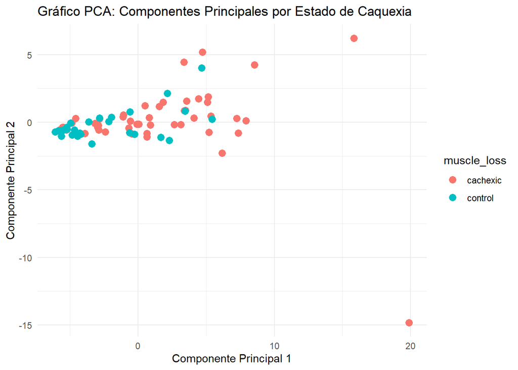

```r
#Según el grupo

puntuaciones_pca <- as.data.frame(pca_result$x)
puntuaciones_pca$muscle_loss <- colData(se)$muscle_loss


# Visualiza las primeras dos componentes principales
library(ggplot2)
ggplot(puntuaciones_pca, aes(x = PC1, y = PC2, color = muscle_loss)) +
  geom_point(size = 3) +
  labs(title = "Gráfico PCA: Componentes Principales por Estado de Caquexia",
       x = "Componente Principal 1",
       y = "Componente Principal 2") +
  theme_minimal()
```

```r
# Comparar medias de la PC1
t.test(PC1 ~ muscle_loss, data = puntuaciones_pca)
```

```
##
##  Welch Two Sample t-test
##
## data:  PC1 by muscle_loss
## t = 4.2476, df = 74.968, p-value = 6.133e-05
## alternative hypothesis: true difference in means between group cachexic and group control is not equal to 0
## 95 percent confidence interval:
##  2.230164 6.169675
## sample estimates:
## mean in group cachexic  mean in group control
##               1.636332              -2.563587
```

```r
# Comparar medias de la PC2
t.test(PC2 ~ muscle_loss, data = puntuaciones_pca)
```

```
##
##  Welch Two Sample t-test
##
## data:  PC2 by muscle_loss
## t = 0.97254, df = 65.435, p-value = 0.3344
## alternative hypothesis: true difference in means between group cachexic and group control is not equal to 0
## 95 percent confidence interval:
##  -0.4626115  1.3410497
## sample estimates:
## mean in group cachexic  mean in group control
##              0.1711243             -0.2680948
```

La primera componente principal explica un 40,43% de la variabilidad

Los metabolitos creatinina y glutamina tienen las cargas más altas (0.1755 y 0.1709, respectivamente), lo que indica que estas dos variables son las que más contribuyen a la PC1. Un aumento en estas variables se correlaciona con un aumento en la puntuación de PC1. Todas las variables mostradas tienen cargas positivas, lo que significa que aumentos en estas variables están asociados con un aumento en PC1. LA PC2 explica un 8.18% adicional, siendo Acetato y 3-Hidroxiisovalerato (0.2192 y 0.2046, respectivamente) las que más contribuyen a la PC2.

En el gráfico de dispersión de PCA, usando PC1 y PC2, se representan según el grupo al que pertenece el paciente. Esto permite evaluar visualmente si existen agrupaciones diferenciadas entre grupos. Se aprecian diferencias, sobre todo en PC1, que son más altas en el grupo con caquexia que el grupo control.

La prueba t en PC1 muestra un valor p de 6.133e-05, indicando una diferencia significativa en las medias entre los dos grupos. Además, la diferencia de medias entre los grupos es importante, los pacientes con caquexia tienen una media positiva (1.636), mientras que las de control tienen una media negativa (-2.564).

En cambio, la prueba t en PC2 muestra un valor p de 0.3344, por tanto, no existe una diferencia significativa en las medias de PC2 entre los grupos.

Se llega a la conclusión de que PC1 es la componente principal que muestra una diferencia significativa entre los grupos de caquexia y control. La diferencia de medias y el valor p extremadamente bajo sugieren que PC1 podría estar relacionado con cambios metabólicos importantes asociados con la caquexia. En cambio en PC2, las diferencias entre los grupos no son relevantes.

5. Cread un repositorio de github –> https://github.com/sofilinares/Linares-Amoros-Sofia-PEC1